# Title of Blog Post Deliverable

## 2.3 Task3

```r
single_spin <- function(){
  possible_outcomes <- c(rep("red",18), rep("black",18), rep("green",2))
  sample(possible_outcomes, 1)
}

martingale_wager <- function(
  previous_wager
  , previous_outcome
  , max_wager
  , current_budget
){
  if(previous_outcome == "red") return(1)
  min(2*previous_wager, max_wager, current_budget)
}

one_play_2 <- function(previous_ledger_entry, max_wager){
  # Create a copy of the input object that will become the output object
  out <- previous_ledger_entry
  out[1, "game_index"] <- previous_ledger_entry[1, "game_index"] + 1
  out[1, "starting_budget"] <- previous_ledger_entry[1, "ending_budget"]
  out[1, "wager"] <- martingale_wager(
    previous_wager = previous_ledger_entry[1, "wager"]
    , previous_outcome = previous_ledger_entry[1, "outcome"]
    , max_wager = max_wager
    , current_budget = out[1, "starting_budget"]
  )
  out[1, "outcome"] <- single_spin()
  out[1, "ending_budget"] <- out[1, "starting_budget"] +
    ifelse(out[1, "outcome"] == "red", +1, -1)*out[1, "wager"]
  return(out)
}

one_series_2 <- function(
  max_games, starting_budget, winning_threshold, max_wager
){
  # Initialize ledger
  ledger <- data.frame(
      game_index = 0:max_games
    , starting_budget = NA_integer_
    , wager = NA_integer_
    , outcome = NA_character_
    , ending_budget = NA_integer_
  )
  ledger[1, "wager"] <- 1
  ledger[1, "outcome"] <- "red"
  ledger[1, "ending_budget"] <- starting_budget
  for(i in 2:nrow(ledger)){
    #browser()
    ledger[i,] <- one_play_2(ledger[i-1,], max_wager)
    if(stopping_rule(ledger[i,], winning_threshold)) break
  }
  # Return non-empty portion of ledger
  ledger[2:i, ]
}

stopping_rule <- function(
  ledger_entry
  , winning_threshold
){
  ending_budget <- ledger_entry[1, "ending_budget"]
  if(ending_budget <= 0) return(TRUE)
  if(ending_budget >= winning_threshold) return(TRUE)
  FALSE
}

profit <- function(ledger){
  n <- nrow(ledger)
  profit <- ledger[n, "ending_budget"] - ledger[1, "starting_budget"]
  return(profit)
}

require(magrittr)
```

> Code from the teacher Explanation: There are five major functions. They are respectively “single_spin”, “martingale_wager”, “one_play_2”, “one_series_2”, and “stopping_rule”. The function “single_spin” is to simulate the roulette spinning to get the result of this play. The function “martingale_wager” is to decide the wager for this play based on the previous outcome. The function “stopping_rule”,“one_play_2”, and “one_series_2” are the same as “stop_play”,“one_play”,“one_series” respectively mentioned above.

```r
# repeat 10000 times
play_before_stopping <- rep(NA,10000)
# for each play, record the total play times before stopping
for (i in seq_along(play_before_stopping)){
  # get the play information
  ledger <- one_series_2(1000,200,300,100)
  # access the total play numbers
  play_before_stopping[i] <- ledger[nrow(ledger),1]
}
# calculate the average numbers of play before stopping
mean(play_before_stopping)
```

```
## [1] 202.8652
```

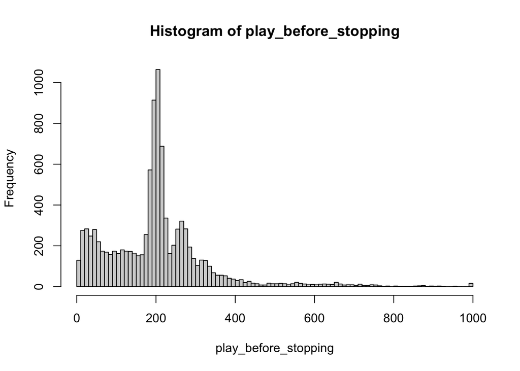

```r
hist(play_before_stopping, breaks = 100)
```

> The average number of play is around 200. Following is the parametes information of this simulation: B = 200, W = 300, L = 1000, M = 100 The first step to get the average play numbers is to decide the number of repeats. In this situation, I decided to play roulette 10000 times. Then, I need to calculate the play number of each time. This step is achieved by a computer. I used my computer to simulate one roulette play and repeated it 10000 times. Play will stop in the following three cases, which mimic what might happen in real life: 1. B = 0, which mimics the situation that a gambler loses all the money. 2. W = 300, which means that a gambler is very lucky and he wins the most money he can win. Thus, the play should stop. 3. L = 1000, which means a gambler runs out of all play chances. In real life, cases 2 and 3 are likely to be set by dealers to protect their own interests.

## 2.4 Task4

> Limitations of the simulation: 1. Not enough repetitions. Due to the limited computation speed, I set the repetitions as 10000 but it actually only covers a small subset of the real situation. 2. In the simulation, I used R’s random number generator to simulate the process of turning the roulette. However, the random number generator is pseudo and it follows certain rules to generate random numbers. Thus, it’s not a perfect way to simulate the real situation. 3. In a real situation, besides the three limitations (budget threshold, maximum number of plays, the casino wager limit), there may be other limitations like the minimum wager for each play.

# 3 Conclusions

The essence of the Martingale strategy is increasing the chances of a gambler turning a loss into a win. In other words, one win can offset all previous losses. However, in a real situation, this strategy is very risky and restrictive. If a gambler’s starting budget is small, it is difficult for him to use this strategy to make money because he probably loses all his money before a win appears. A Low time threshold for a gambler with a large starting budget will cause the same problem. If a gambler’s starting budget is large but the Casion wager limit is small. It’s also very difficult for him to win the money because after he has lost several times, the required wager has exceeded the limit. In this case, this strategy is no longer applicable. From my perspective, if a gambler with a large starting budget is in a casino without the time and wager restrictions, this strategy can be regarded as useful as long as the gambler is not too greedy and his luck is not too bad.